# Predictability Preregistration

Rondeline M. Williams

## **Study Information**

### Title

Effect of background noise predictability on novel word learning in preschool-age children

### Description

This study explores how preschool-age children learn novel words under background noise varying in predictability of noise onset.

### Contributors

Rondeline M. Williams & Michael C. Frank

### Affiliated Institutions

Stanford University

## **Design Plan**

### Study Type

Experiment: A researcher randomly assigns treatments to study subjects, this includes field or lab experiments. This is also known as an intervention experiment and includes randomized controlled trials.

### Blinding

For studies that involve human subjects, they will not know the treatment group to which they have been assigned. Personnel who analyze the data collected from the study are not aware of the treatment applied to any given group.

### Study Design

Participants will complete the experimental session remotely via Zoom. The experimenter will collect consent from the caregiver to conduct and record the study before preparing the screen for remote testing (including a video and audio check). Participants will first be introduced to an animated North American female character named Maggie. Maggie will tell participants that she has four new toys she would like to show them and teach participants their names. The four novel objects and names were selected from the NOUN Database (Horst and Hout 2016). The objects are distinct in color, shape, and (presumably) texture. The labels were distinct in number of syllables (two labels had one syllable and two labels had two syllables) and phonetic quality. Object and label pairings will be counterbalanced, such that each of the four objects will have four possible labels between subjects. During the initiation phase, the objects will be presented in silence and in pairs (pairs will be counterbalanced across conditions) for five seconds. During each of the eight training trials, one novel object will appear in the center of the screen. After 1s, Maggie (audio only) will say, “Hey, look at this! This is the [novel label]. Do you see the [novel label]? Now the [novel label] is going over here. Wow, a [novel label]!” As the audio plays, the novel object will move around the screen, following the same path across trials. Each training trial will be ~13s. Each of the four novel objects will be presented twice during the training trials. The order in which they are presented will be counterbalanced. Participants will be assigned to one of three conditions. In the continuous condition, training trials will be paired with sustained multi-talker babble. In the intermittent-predictable condition, training trials will be paired with equally-spaced blocks of multi-talker babble. Each block will be 600ms in length with 100ms of an auditory on-ramp (in which the auditory signal steadily increases to its intended sound level) and 100ms of an auditory off-ramp (in which the auditory signal steadily decreases to 0dB. Noise blocks will be equally spaced by 300ms of silence blocks. In the intermittent-unpredictable condition, training trials will be paired with 600ms of noise blocks with silence blocks of 0ms (where two noise blocks are placed next each other) and 1s. Multi-talker babble was engineered using Audacity and Praat (“Audacity,” n.d.; Boersma and Weenink 2020). Five female fluent English speakers (all adult graduate students from Stanford University) were recorded separately reading one of three short children’s stories. Each recording was then edited to remove all silences greater than 300ms. Then, each audio file was equalized to 60dB before being combined into one stereo track. 600ms noise blocks were randomly selected from the 53s audio and did not overlap between blocks. During the test phase, participants will be shown randomized and counterbalanced pairs of the four novel objects side-by-side. At the beginning of each trial, one pair will appear on the screen (one on the left side of the screen and the other on the right). After 1s of silence, Maggie (audio only) will say, “I’m looking for the [novel label]. Which one is the [novel label]?” They will be asked to point to the object Maggie is asking about. After the child points to one object, the experimenter will ask the child to say the color of the object to which they are pointing. Caregivers will be asked not to interfere with participant’s answers but will be permitted to assist children with color labels if they are not yet able to label colors. Experimenters may prompt participants up to twice if they are initially unresponsive. Participants will complete a total of 12 test trials in which each of the four novel objects will be requested three times.

### Randomization

Each of the novel objects (orange, pink, blue, and green) and labels (coodle, glark, toma, vep) will be randomized and counterbalanced across conditions and sessions, such that every possible combination will be presented. Trial order will be determined using block randomization.

## **Sampling Plan**

### Existing Data

Registration prior to creation of data

### Data Collection Procedures

Participants will be recruited through an IRB-approved online research platform. Participants will be between 3;0 years and 5;11 years at time of test, must have normal or corrected-to-normal vision, typical hearing, no reported cognitive or neurodevelopmental delays/disorders, and must be exposed to English at least 75% of the time at home.

### Sample Size

For the first iteration of this study, we will recruit up to 45 participants to the predictable condition and 45 participants to the continuous condition.

### Sample Size Rationale

We used the Bayes Factor Design Analysis (BFDA) to construct a sequential sample design with a maximal n (Stefan et al. 2019).

```r
library(BFDA)
#Note: Average run time is about 2 hours
sim_H1 <- BFDA.sim(
  expected.ES = rnorm(n = 1000, mean = 0.5, sd = 0.1),
  type = "t.between",
  prior = list("Cauchy", list(prior.location=0, prior.scale=sqrt(2)/2)),
  n.min = 15,
  n.max = 150,
  boundary = 3,
  stepsize = 1,
  design = "sequential",
  B= 1000,
  verbose = TRUE,
  cores = 4,
  seed = 7)
```

```
## [1] "Simulation started at 2020-11-20 20:02:09"
```

```
## [1] "Simulation finished at 2020-11-20 20:07:11"
## Duration: Time difference of 5.038242 mins
```

```r
sim_H0 <- BFDA.sim(
  expected.ES = 0,
  type = "t.between",
  prior = list("Cauchy", list(prior.location = 0, prior.scale = sqrt(2)/2)),
  n.min = 15,
  n.max = 150,
  boundary = 2,
  stepsize = 1,
  design = "sequential",
  B= 1000,
  verbose = TRUE,
  cores = 4,
  seed = 7)
```

```
## [1] "Simulation started at 2020-11-20 20:07:11"
## [1] "Simulation finished at 2020-11-20 20:08:36"
## Duration: Time difference of 1.411374 mins
```

```r
BFDA.analyze(sim_H1, design="sequential", n.min=15, n.max=150, boundary=3)
```

```
##                                outcome percentage
## 1 Studies terminating at n.max (n=150)       0.1%
## 2    Studies terminating at a boundary      99.9%
## 3       --> Terminating at H1 boundary      68.9%
## 4       --> Terminating at H0 boundary        31%
##
## Of 0.1% of studies terminating at n.max (n=150):
## 0% showed evidence for H1 (BF > 3)
## 0.1% were inconclusive (3 > BF > 1/3)
## 0% showed evidence for H0 (BF < 1/3)
##
## Average sample number (ASN) at stopping point (both boundary hits and n.max): n = 31
##
## Sample number quantiles (50/80/90/95%) at stopping point:
## 50% 80% 90% 95%
##  23  41  57  72
```

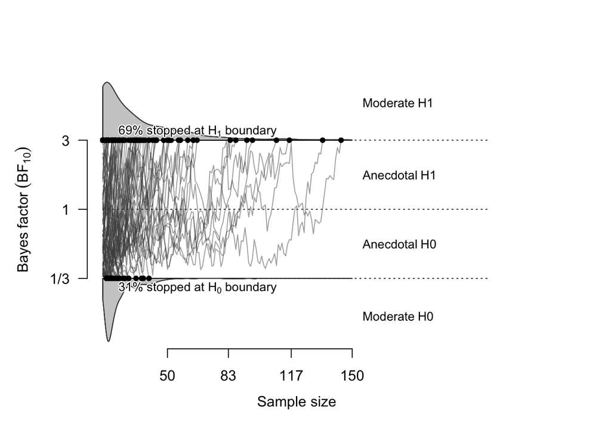

```r
plot(sim_H1, n.min=15, boundary=c(1/3, 3), n.trajectories = 140)
```

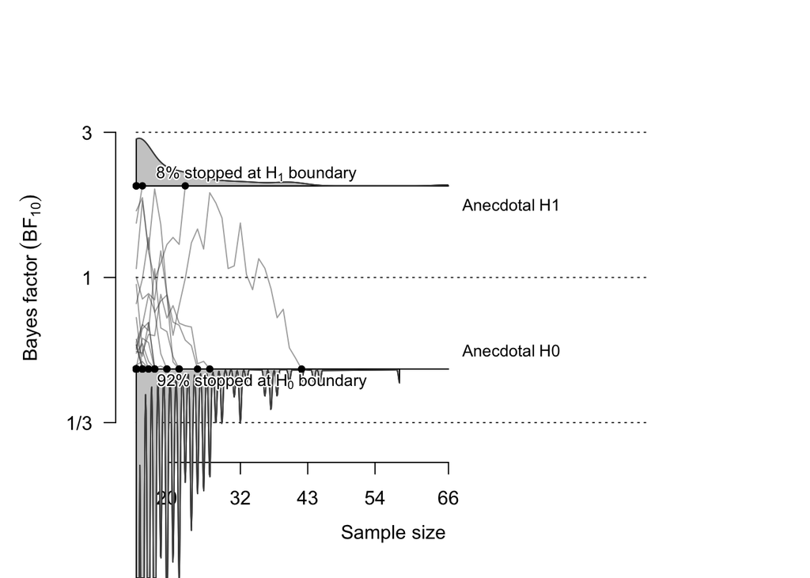

```r
plot(sim_H0, n.min=15, boundary=c(1/2, 2))
```

These simulations suggest a sample size of 41 per condition to reach 80% power with an average sample number of 31 across the 1000 simulations.

### Stopping Rule

We plan to collect data until we reach a Bayes Factor of 3 or until we collect data for 45 participants in each condition, whichever comes first.

## **Variables**

### Manipulated Variables

We will manipulate the degree of background noise predictability during the training phase of the experimental session. In the intermittent-predictable condition, background noise will consist of ~16 600ms equally-spaced blocks of multitalker babble and 300ms of silence between each block. In the intermittent-unpredictable condition, background noise will consist of ~16 600ms of multitalker babble interspersed with silence intervals of 0ms-1000ms. In the continuous condition, background noise will play from the beginning to the end of each training trial.

### Measured Variables

The primary outcome measure is accuracy of identifying labels for the four presented novel objects. There will be four novel objects and four novel labels (each with a single pair across trials). Participants will be shown two of the four possible objects and asked to point to the correct object based on the spoken label. In this forced-choice design, participants have a 50% chance of correctly identifying the novel object in each test trial but a 25% chance of correctly mapping the label to its novel object. The predictor variable we will also measure is participant age. Participants will be 3;0 years to 5;11 years at time of test.

## **Analysis Plan**

### Statistical Models

```r
library(dplyr)
library(rstanarm)
library(brms)
library(janitor)
```

```r
library(ggplot2)
library(bayesplot)
library(pscl)
library(bayestestR)
library(BayesFactor)
library(sjPlot)
data <- read.csv("simulated_data.csv")
```

```r
tidy_data <- data %>%
  clean_names() %>%
  select(-test_date) %>%
  group_by(participant_id, condition) %>%
  mutate(avg_accuracy = mean(accuracy))
```

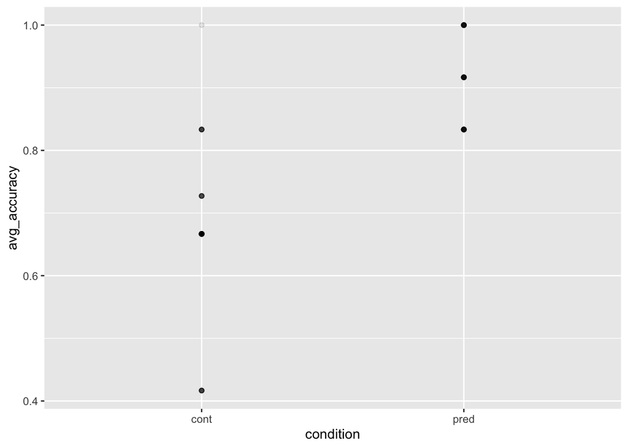

```r
ggplot(tidy_data,
       mapping = aes(x = condition, y = avg_accuracy)) +
  geom_point(alpha = 0.1)
```

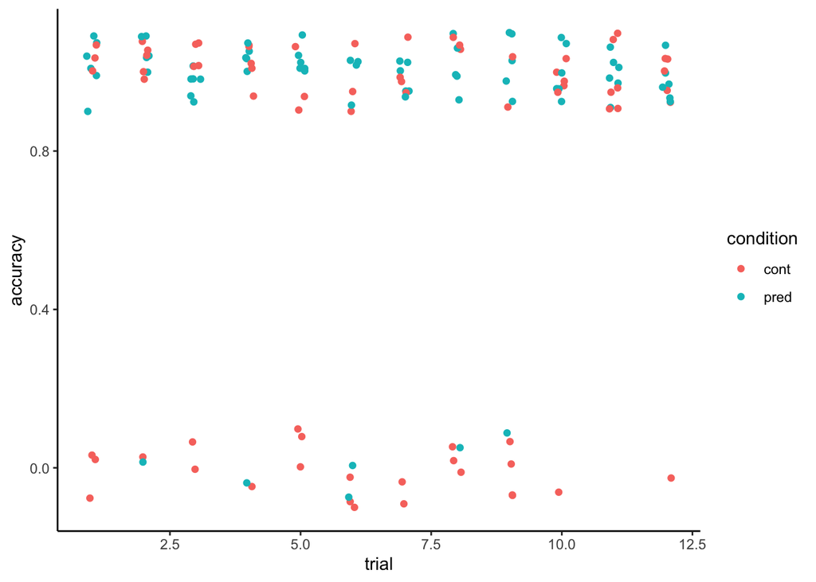

```r
ggplot(tidy_data,
       mapping = aes(x = trial, y = accuracy, col = condition)) +
  geom_jitter(width = 0.1, height = 0.1) +
  theme_classic()
```

```r
pred_cont_glmer <- stan_glmer(accuracy ~ condition * age + (1|participant_id), data = tidy_data, family = binomial)
summary(pred_cont_glmer)
```

```
##
## Model Info:
##  function:     stan_glmer
##  family:       binomial [logit]
##  formula:      accuracy ~ condition * age + (1 | participant_id)
##  algorithm:    sampling
##  sample:       4000 (posterior sample size)
##  priors:       see help('prior_summary')
##  observations: 144
##  groups:       participant_id (13)
##
## Estimates:
##                                                 mean   sd   10%   50%   90%
## (Intercept)                                   -0.3    1.5 -2.1  -0.3   1.6
## conditionpred                                  1.1    2.4 -2.0   1.1   4.1
## age                                            0.2    0.3 -0.2   0.2   0.7
## conditionpred:age                              0.2    0.6 -0.5   0.2   1.0
## b[(Intercept) participant_id:PP001]           -0.1    0.5 -0.6   0.0   0.3
## b[(Intercept) participant_id:PP002]           -0.3    0.4 -0.9  -0.2   0.1
## b[(Intercept) participant_id:PP003]            0.1    0.5 -0.3   0.0   0.7
## b[(Intercept) participant_id:PP004]            0.0    0.4 -0.5   0.0   0.4
## b[(Intercept) participant_id:PP005]            0.1    0.4 -0.3   0.0   0.5
## b[(Intercept) participant_id:PP006]           -0.1    0.4 -0.5   0.0   0.4
## b[(Intercept) participant_id:PP007]            0.0    0.4 -0.5   0.0   0.4
## b[(Intercept) participant_id:PP008]            0.1    0.4 -0.3   0.0   0.5
## b[(Intercept) participant_id:PP009]            0.1    0.5 -0.4   0.0   0.6
## b[(Intercept) participant_id:PP010]            0.0    0.4 -0.4   0.0   0.5
## b[(Intercept) participant_id:PP011]           -0.2    0.5 -0.8  -0.1   0.2
## b[(Intercept) participant_id:PP012]            0.2    0.5 -0.2   0.1   0.9
## b[(Intercept) participant_id:PP013]            0.2    0.4 -0.2   0.1   0.7
## Sigma[participant_id:(Intercept),(Intercept)]  0.3    0.5  0.0   0.1   0.7
##
## Fit Diagnostics:
##            mean   sd   10%   50%   90%
## mean_PPD 0.8    0.0  0.7   0.8   0.8
##
## The mean_ppd is the sample average posterior predictive distribution of the outcome variable (for details see help('summary.stanreg')).
##
## MCMC diagnostics
##                                               mcse Rhat n_eff
## (Intercept)                                   0.0  1.0  2901
## conditionpred                                 0.1  1.0  1748
## age                                           0.0  1.0  2870
## conditionpred:age                             0.0  1.0  1847
## b[(Intercept) participant_id:PP001]           0.0  1.0  3499
## b[(Intercept) participant_id:PP002]           0.0  1.0  2299
## b[(Intercept) participant_id:PP003]           0.0  1.0  3901
## b[(Intercept) participant_id:PP004]           0.0  1.0  4501
## b[(Intercept) participant_id:PP005]           0.0  1.0  3346
## b[(Intercept) participant_id:PP006]           0.0  1.0  4012
## b[(Intercept) participant_id:PP007]           0.0  1.0  4540
## b[(Intercept) participant_id:PP008]           0.0  1.0  3083
## b[(Intercept) participant_id:PP009]           0.0  1.0  4157
## b[(Intercept) participant_id:PP010]           0.0  1.0  3980
## b[(Intercept) participant_id:PP011]           0.0  1.0  2760
## b[(Intercept) participant_id:PP012]           0.0  1.0  2703
## b[(Intercept) participant_id:PP013]           0.0  1.0  3599
## Sigma[participant_id:(Intercept),(Intercept)] 0.0  1.0  2017
## mean_PPD                                      0.0  1.0  4876
## log-posterior                                 0.1  1.0  1195
##
## For each parameter, mcse is Monte Carlo standard error, n_eff is a crude measure of effective sample size, and Rhat is the potential scale reduction factor on split chains (at convergence Rhat=1).
```

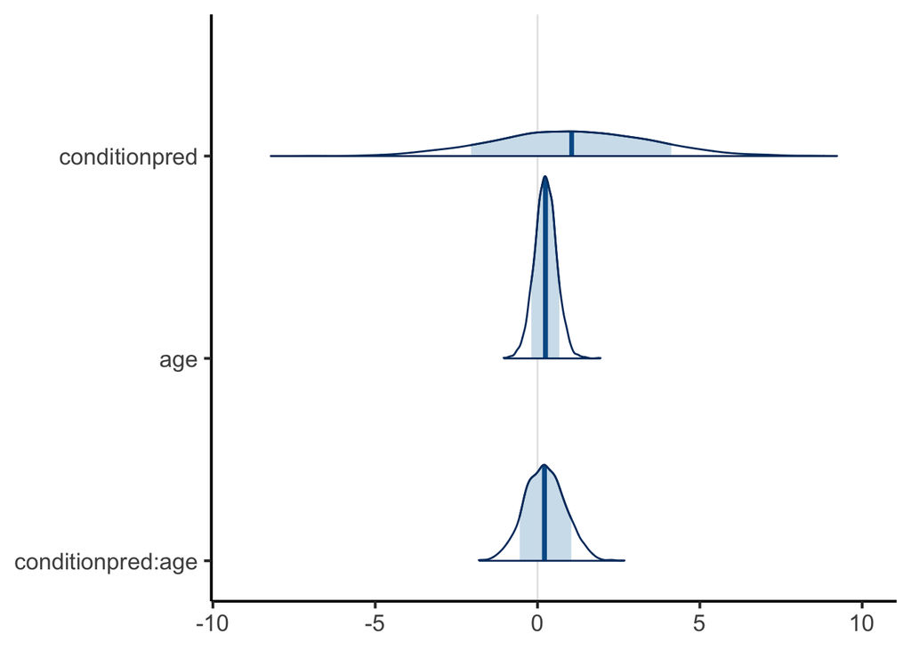

```r
posterior <- as.matrix(pred_cont_glmer)

mcmc_areas(posterior,
           pars = c("conditionpred", "age", "conditionpred:age"),
           prob = 0.8) +
  theme_classic(base_size = 16)
```

```r
#ggsave("bayesplot_spl.png")

get_stan_glmer_reporting_values <- function(model, cond, digits=2) {
  ci95 <- posterior_interval(model, prob = 0.95, pars = cond)
  ci89 <- posterior_interval(model, prob = 0.89, pars = cond) # 89% CIs as recommended by Kruschke and others
  pd = p_direction(model)
  pd = pd[which(pd$Parameter==cond),]$pd
  ci = round(c(ci95,ci89,pd), digits)
  names(ci) = c("95pLB","95pUB","89pLB","89pUB","pd") # 95% and 89% lower and upper bounds
  beta = round(model$coefficients[cond], digits)
  return(c(beta,ci))
}

get_stan_glmer_reporting_values(pred_cont_glmer, "conditionpred")
```

```
## conditionpred         95pLB         95pUB         89pLB         89pUB
##          1.05         -3.61          5.69         -2.83          4.85
##            pd
##          0.67
```

```r
get_stan_glmer_reporting_values(pred_cont_glmer, "age")
```

```
##   age 95pLB 95pUB 89pLB 89pUB    pd
##  0.24 -0.43  0.92 -0.30  0.79  0.77
```

```r
ttestBF(formula = accuracy ~ condition, data = tidy_data)
```

```
## Bayes factor analysis
## --------------
## [1] Alt., r=0.707 : 129.5333 ±0%
##
## Against denominator:
##   Null, mu1-mu2 = 0
## ---
## Bayes factor type: BFindepSample, JZS
```

```
## Instead of posterior_linpred(..., transform=TRUE) please call posterior_epred(), which provides equivalent functionality.
```

```
## Note: uncertainty of error terms are not taken into account. You may want to use `rstantools::posterior_predict()`.
```

```
## Instead of posterior_linpred(..., transform=TRUE) please call posterior_epred(), which provides equivalent functionality.
```

```
## Note: uncertainty of error terms are not taken into account. You may want to use `rstantools::posterior_predict()`.
```

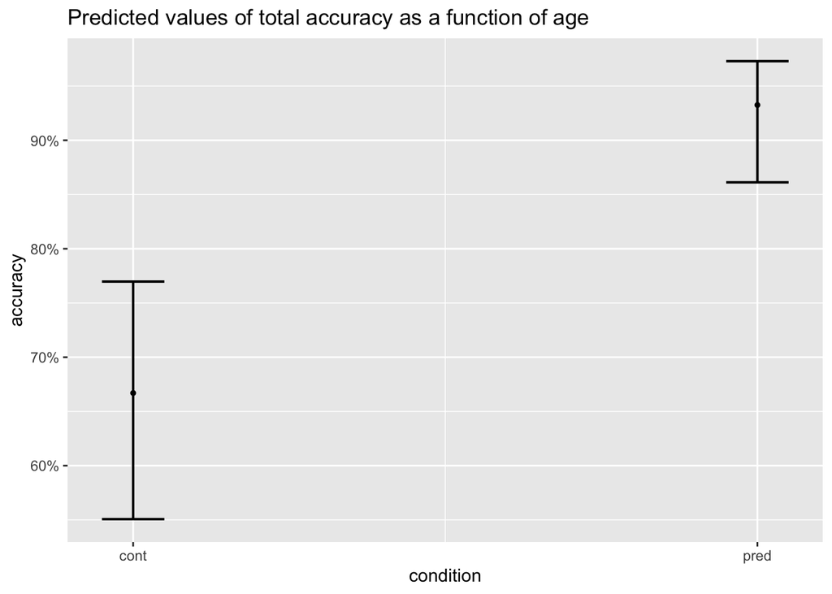

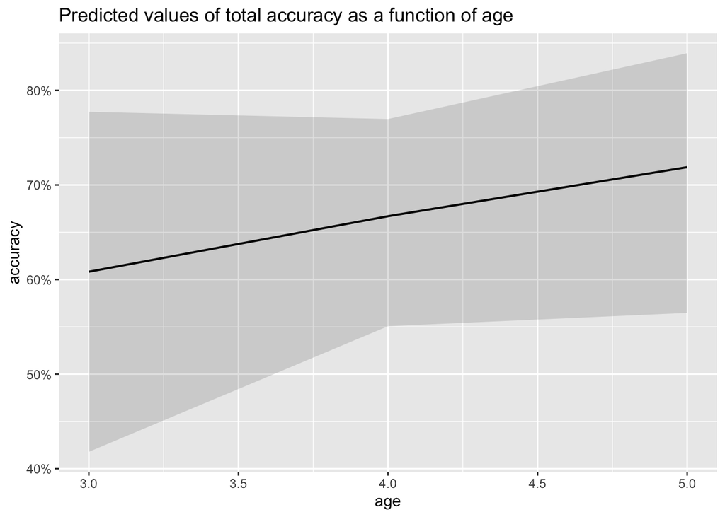

```r
plot_model(pred_cont_glmer, type = "pred", vars = c("accuracy", "age"),
           title = "Predicted values of total accuracy as a function of age",
           show.p = TRUE)
```

### Inference Criteria

We will use Bayes factor for determining if our regression models and t-tests show a significant difference between H0 and H1.

### Data Exclusion

Participants who look away from the screen with both eyes for more than 50% of the 8 training trials and/or with fewer than four data points (completed fewer than four test trials) will be excluded from analysis. Trials with caregiver interference (caregiver points to the screen or tells the child the correct objects) will also be excluded.

### Exploratory Analysis

In addition to our registered confirmatory analysis, we plan to analyze gender and trial order effects as exploratory analyses only.

## References

“Audacity.” n.d. *Audacity*. https://www.audacityteam.org.

Boersma, Paul, and David Weenink. 2020. “Praat: Doing Phonetics by Computer.” *Praat*. http://www.praat.org/.

Horst, Jessica S., and Michael C. Hout. 2016. “The Novel Object and Unusual Name (NOUN) Database: A Collection of Novel Images for Use in Experimental Research.” *Behavior Research Methods* 48 (4): 1393–1409. https://doi.org/10.3758/s13428-015-0647-3.

Stefan, Angelika M., Quentin F. Gronau, Felix D. Schönbrodt, and Eric-Jan Wagenmakers. 2019. “A Tutorial on Bayes Factor Design Analysis Using an Informed Prior.” *Behavior Research Methods* 51 (3): 1042–58. https://doi.org/10.3758/s13428-018-01189-8.